# Pittsburgh Trees

Nafissa Bia

December 3, 2024

## Introduction

This paper analyzes data on trees from Pittsburgh, Pennsylvania. The dataset was obtained from [Data.gov](https://catalog.data.gov/dataset/city-of-pittsburgh-trees) and contains detailed information about trees maintained by The City of Pittsburgh Department of Public Works Forestry Division. The dataset consists of 45709 rows and 59 columns, with each row representing a single tree located within the city’s boundaries. The data was collected through physical inspections and monitoring efforts and was last updated in 2020.

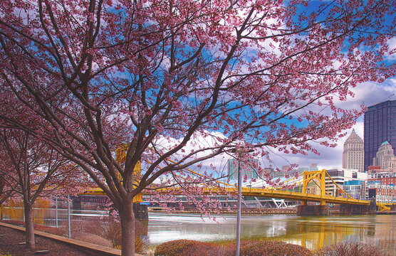

Each tree is identified by location-specific details, such as `address_number` and `street_name`, and geographic coordinates, such as`longitude` and `latitude`. The dataset includes categorical variables, like `street`, `common_name`, `scientific_name`, and `growth_space_type` (‘Well or Pit’, ‘Open or Unrestricted’, etc.) that describe the tree’s location, identity, and growing conditions. Other categorical variables, such as `land_use` (‘Residential’, ‘Vacant’, etc.), indicate the type of property on which the tree is situated.

There are also several continuous variables that characterize the physical dimensions and environmental benefits provided by each tree. These include measurements like `height`, `width`, `growth_space_length`, `growth_space_width`, and `diameter_base_height`, which give information on the tree’s size and growth space. Environmental benefits, such as stormwater management and air quality improvement, are quantified through variables like `co2_benefits_maint_lbs`, `air_quality_benfits_so2dep_lbs`, and `stormwater_benefits_runoff_elim.` Additionally, variables like `energy_benefits_electricity_dollar_value` and `energy_benefits_gas_dollar_value` estimate energy savings provided by each tree in terms of reducing electricity and gas usage.

All the tree benefits from this dataset were calculated using the [National Tree Benefit Calculator Web Service](http://www.treebenefits.com/calculator/webservicedescription.cfm), which estimates the environmental benefits of individual trees based on their species, size (e.g diameter at breast height), and location/regional climate. It uses scientific models developed by the U.S. Forest Service and other research institutions to quantify benefits like carbon dioxide reduction, stormwater management, or air quality improvement in units such as pounds, gallons, etc., or in dollars to represent the financial value of the ecosystem services provided by these trees.

Overall, this dataset gives a comprehensive view of the value and condition of Pittsburgh’s urban forest.

## Research Questions

After an initial study of the variables contained in this dataset, here are a few questions of interest:

- Which factors influence the amount of stormwater runoff absorbed by trees?
- Do certain tree species provide more ecological benefits, such as increased stormwater runoff elimination or higher capture of CO$_2$?
- Can tree dimensions predict their impact on air quality?
- Do trees with overhead utilities grow differently or provide fewer benefits?
- Is there a significant difference in the CO$_2$ benefits between trees located in residential areas versus vacant or industrial areas?
- How are trees distributed across different neighborhoods or wards in Pittsburgh?
- Are there clusters of tree species within certain areas of the city?
- Do trees closer to each other in certain areas provide cumulative environmental benefits (e.g., stormwater management or CO$_2$ reduction)?

## Exploratory Data Analysis

- **Check for missing values**: Some NA values were entered as ‘N/A’, so that was corrected when reading in the data. Using summary() showed that there are many missing values for most columns in this dataset. **For better visualizations, all the observations with NA values are being omitted**. For categorical variables, count() was used to get a glimpse of categories (e.g., counts of trees in each neighborhood or by land use).
- **Exploring Quantitative Variables**: For some numeric variables like `height`, `diameter_base_height`, and `overall_benefits_dollar_value`, plotting histograms and boxplots showed unimodal right-skewed distributions with many high outliers and relatively small IQR values. Some of these graphs are shown below.

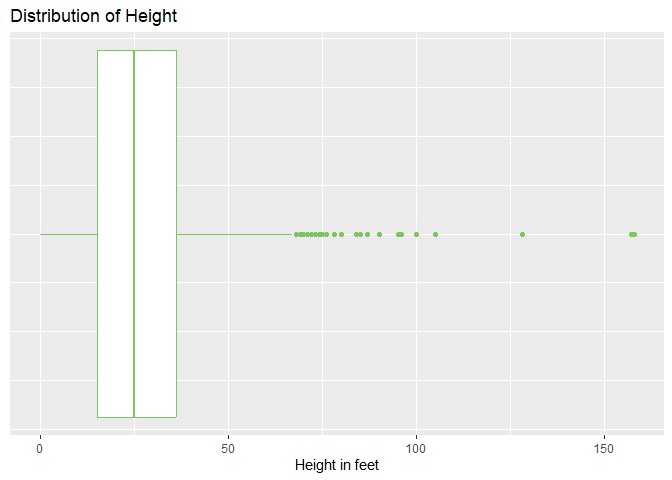

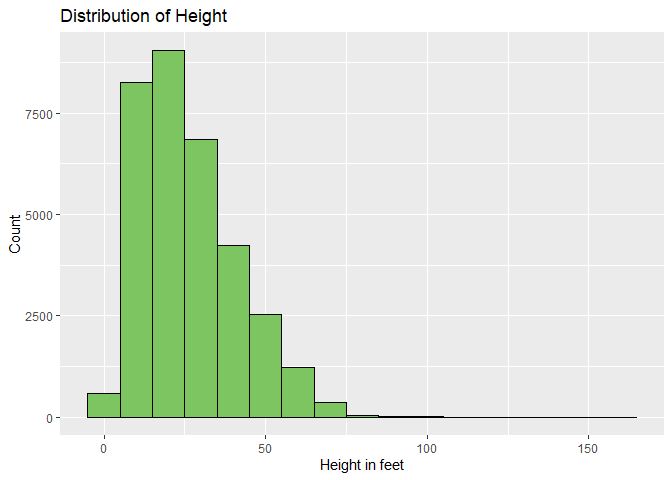

```
##    Min. 1st Qu.  Median    Mean 3rd Qu.    Max.
##    0.00   15.00   25.00   27.54   36.00  158.00
```

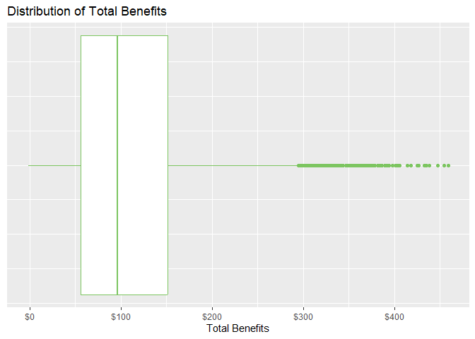

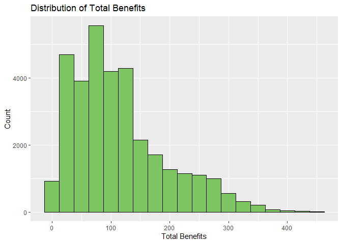

```
##    Min. 1st Qu.  Median    Mean 3rd Qu.    Max.
##  -1.334  56.084  96.551 113.386 151.250 459.493
```

Additionally, there weren’t values that seemed wrong (e.g., negative values) for the most part. However, ‘Colorado spruce’ trees were found to have negative total environmental benefits, which could be explained by their poor adaptation to local urban conditions, such as drought, heat, and shade stress (source: [NC Cooperative Extension](https://henderson.ces.ncsu.edu/2020/07/colorado-blue-spruce-issues/#:~:text=Below%204000%20feet%20Colorado%20blue,spruce%20also%20needs%20dry%20air.) ). These factors reduce their growth and canopy size, limiting benefits like carbon sequestration and stormwater management. Additionally, high maintenance costs, including pruning or pest control, may outweigh their environmental contributions, leading to a net negative value in the benefit model.

- **Transformations**: Since some of the quantitative variables, like `height` and `width`, are very right-skewed, using a log transformation may yield better results on the graphs:

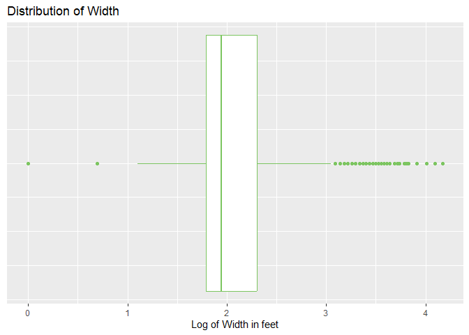

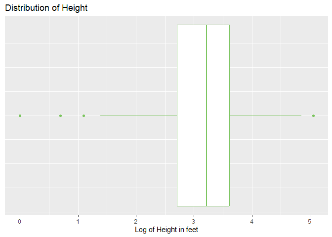

For `width`, using a log transformation didn’t improve the visualization considerably. For `height`, the transformation shows a lot less high outliers but a slightly left-skewed distribution with some low outliers. Overall, using a log transformation doesn’t seem to help considerably.

- **Variable and value names**
  - Some of the variable names are slightly lengthy, especially the variables about environmental benefits. Thus these variables have been recoded to have shorter names.
  - For some of the categorical variables, there are inconsistencies in the names of the values. For instance, for the variable `growth_space_type`, there were values such as ‘Well or Pit’ and ‘Well/Pit’ or ‘Tree Lawn’ and ‘Tree Law or Parkway’, which are recoded to be in the same categories. Some of recoded values are displayed below.

Initial values for `growth_space_type`:

```
## # A tibble: 7 × 1
##   growth_space_type
##   <chr>
## 1 Well or Pit
## 2 Open or Unrestricted
## 3 Tree Lawn or Parkway
## 4 Open or Restricted
## 5 Median
## 6 Raised Planter
## 7 Island
```

Recoded values for `growth_space_type`:

```
## # A tibble: 7 × 1
##   growth_space_type
##   <chr>
## 1 Well/Pit
## 2 Open
## 3 Tree Lawn
## 4 Restricted
## 5 Median
## 6 Raised Planter
## 7 Island
```

Initial values for `overhead_utilities`:

```
## # A tibble: 3 × 1
##   overhead_utilities
##   <chr>
## 1 No
## 2 Conflicting
## 3 Yes
```

Recoded values for `overhead_utilities`:

```
## # A tibble: 2 × 1
##   overhead_utilities
##   <chr>
## 1 No
## 2 Yes
```

- **Exploring categorical variables**

Here are the distributions of some categorical variables in this dataset:

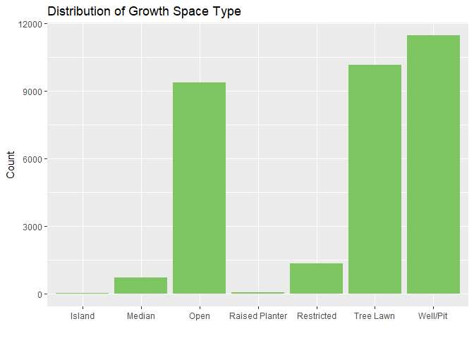

*There is a considerable variation between growth space types. ‘Well/Pit’, ‘Tree Lawn’, and ‘Open’ are by far the most common growth space types. ‘Island’ and ‘Raised Planter’ are the least common spaces.*

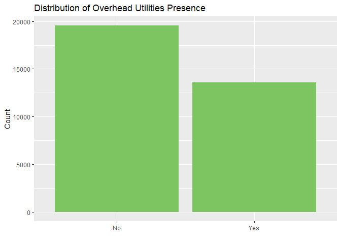

*There are many trees both with and without overhead utilities, but most trees do not have overhead utilities.*

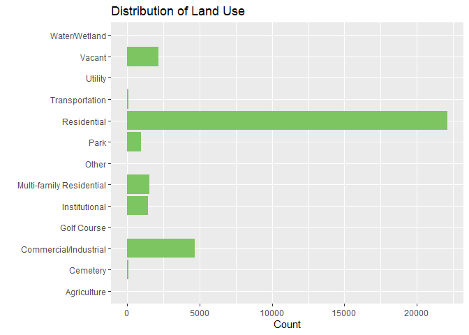

*The most common land use category for trees in this dataset is ‘Residential’, followed by ‘Commercial/Industrial’ and ‘Vacant’. There are relatively very small numbers of trees in other types of land use, such as ‘Water/Wetland’, ‘Golf Course’, and ‘Agriculture’.*

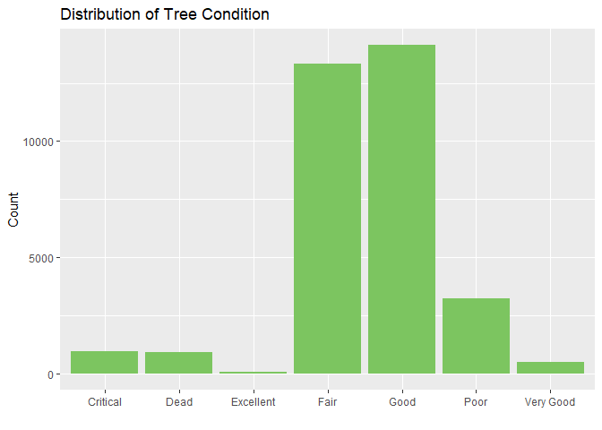

*Most trees are in ‘Good’ or ‘Fair’ condition, while very few trees are in ‘Excellent’ or ‘Very Good’ condition. The numbers of trees in ‘Critical’ and ‘Dead’ conditions are roughly the same.*

- **Exploring pairs of potentially related variables**: We will now explore pairs of potentially related variables to identify relationships and interactions that could emerge when included in the same models.

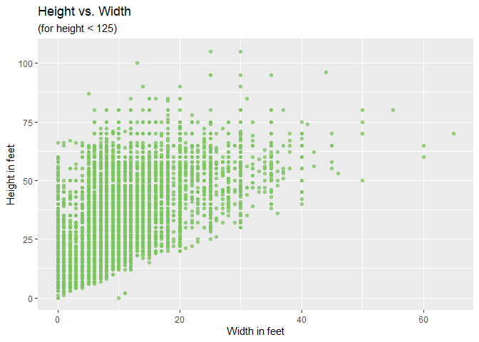

*This scatter plot shows a weak to moderate positive linear relationship between tree height and width for values of height less than 125 feet (filtered to exclude a few extreme outliers). As the width of a tree increases, its height tends to increase as well. Trees with widths under 20 feet vary widely in height, while trees with larger widths tend to have heights within a more limited range, which could be explained by the fact that there are fewer trees with larger widths (the outliers). It should also be noted that height and width both have discrete values only, which is reflected in the scatter plot.*

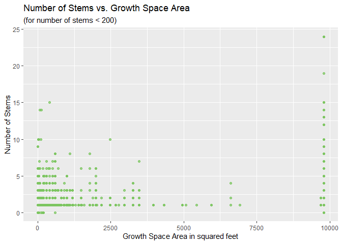

*This plot shows the relationship between a tree’s number of stems and the area of its growth space. There doesn’t seem to be a linear relationship between number of stems and growth space area, though a smaller growth space occasionally supports trees with more stems, and only a small number of trees have both high growth space area and many stems.*

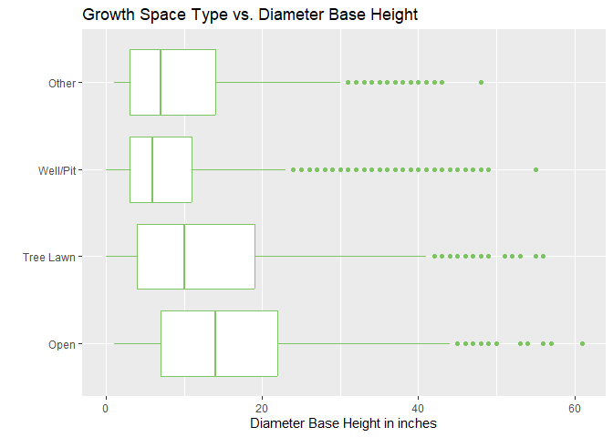

*These boxplots show how the diameter at base height of trees differs across types of growth spaces. Trees in ‘Open’ and ‘Tree Lawn’ spaces have larger median diameters and larger Q1 and Q3 values compared to trees in ‘Well/Pit’ and ‘Other’ spaces. This could suggest that trees in more open spaces are able to grow larger in diameter, potentially due to fewer constraints. Additionally, all the boxplots are right-skewed with lots of high outliers.*

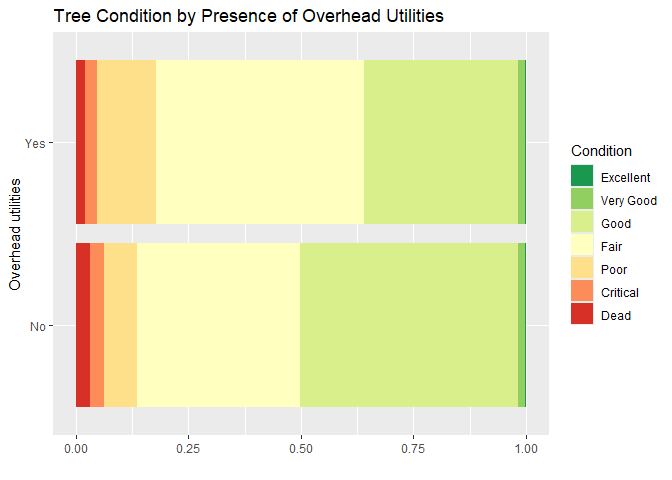

*The stacked bar graphs show the relationship between the presence of overhead utilities and tree condition. Since the distributions of tree condition are not exactly the same for trees with overhead utilities and trees without overhead utilities, there appears to be an association between the presence of overhead utilities and tree condition. There are different proportions of trees in “Poor”, “Fair”, and “Good” conditions in trees with and without overhead utilities, while there are similar proportions of trees in “Critical” and “Very Good” conditions. This may indicate that trees with average health status tend to be more affected by the presence of overhead utilities than trees with very good or very bad health status. For instance, when there are no overhead utilities, there are more trees in “Good” condition than trees in “Fair” condition, whereas when there are overhead utilities, there are more trees in “Fair” condition than trees in “Good” condition.*

## Exploring Research Questions

We are now going to seek for answers to our questions of interest.

### 1. Which factors influence the amount of stormwater runoff absorbed by trees?

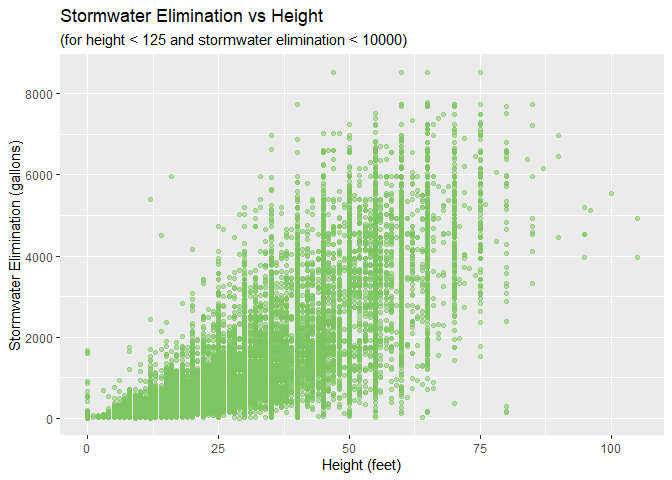

*There seems to be a moderately strong linear relationship between tree height and stormwater runoff elimination. As a tree’s height increases, the amount of stormwater it absorbs tends to increase as well.*

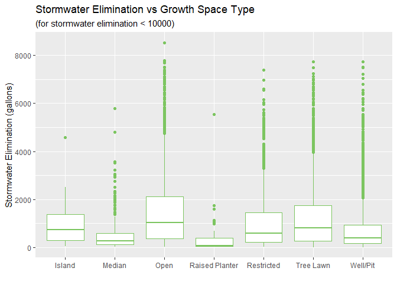

*Stormwater elimination seems to also be influenced by growth space type. ‘Raised Planter’ and ‘Median’ growth space types have the lowest median stormwater elimination while ‘Open’ and ‘Tree Lawn’ have the highest median stormwater elimination, as well as the largest IQR values. All types of spaces show right-skewed distributions of stormwater elimination with high outliers.*

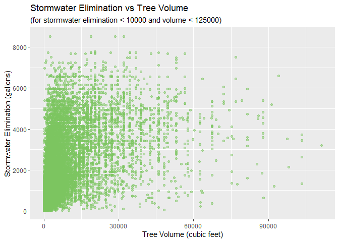

*There doesn’t appear to be a strong linear association between stormwater runoff elimination and volume of trees.*

#### ★ Linear Regression: Factors that influence stormwater elimination

We are going to fit a linear regression model to explore factors that influence stormwater elimination. For now, let’s consider the following predictors: `height`, `diameter_base_height`, `growth_space_type`, `overhead_utilities`, and `condition`. **It should also be noted that the data used for this section is filtered for observations where height is less than 125 feet and stormwater elimination is less than 10000 gallons to exclude extreme outliers**. We will also split the data into training data and testing data using an 80/20 split.

```
## # A tibble: 18 × 5
##    term                            estimate std.error statistic   p.value
##    <chr>                              <dbl>     <dbl>     <dbl>     <dbl>
##  1 (Intercept)                      135.     77.2          1.75 8.04e-  2
##  2 height                            -9.37    0.762      -12.3  1.30e- 34
##  3 I(height^2)                        0.256   0.00981     26.1  1.85e-148
##  4 growth_space_typeMedian          197.     63.2          3.13 1.77e-  3
##  5 growth_space_typeOpen            169.     61.5          2.76 5.87e-  3
##  6 growth_space_typeRaised Planter  235.     86.2          2.73 6.41e-  3
##  7 growth_space_typeRestricted      211.     62.3          3.38 7.18e-  4
##  8 growth_space_typeTree Lawn       186.     61.5          3.02 2.50e-  3
##  9 growth_space_typeWell/Pit        214.     61.5          3.48 5.05e-  4
## 10 diameter_base_height              70.6     1.17        60.3  0
## 11 I(diameter_base_height^2)          1.43    0.0269      53.2  0
## 12 overhead_utilitiesYes            -11.0     4.68        -2.36 1.83e-  2
## 13 conditionVery Good              -780.     49.7        -15.7  3.05e- 55
## 14 conditionGood                   -231.     46.3         -4.98 6.50e-  7
## 15 conditionFair                   -317.     46.3         -6.85 7.57e- 12
## 16 conditionPoor                   -680.     46.7        -14.6  7.07e- 48
## 17 conditionCritical               -905.     48.0        -18.9  7.82e- 79
## 18 conditionDead                   -825.     48.1        -17.2  1.03e- 65
```

```
## # A tibble: 1 × 12
##   r.squared adj.r.squared sigma statistic p.value    df   logLik     AIC     BIC
##       <dbl>         <dbl> <dbl>     <dbl>   <dbl> <dbl>    <dbl>   <dbl>   <dbl>
## 1     0.924         0.924  358.    18924.       0    17 -193380. 386799. 386954.
## # ℹ 3 more variables: deviance <dbl>, df.residual <int>, nobs <int>
```

*$R^2 = 0.9239$, which means that 92.39% of the variation in stormwater elimination is explained by our predictors. `height`, `growth_space_type`, and `diameter_base_height` have a positive association with the amount of stormwater elimination while `overhead_utilities` and `condition` have a negative association with stormwater elimination. For instance, with everything else held constant, we have:*

*- For each additional inch in diameter base height of a tree, we expect the tree to eliminate, on average, 70.56 additional gallons of stormwater;*

*- The average stormwater elimination for trees in a ‘Raised Planter’ growth space type is about 235 gallons higher than for trees in an ‘Island’ growth space type;*

*- The average stormwater elimination for trees in a ‘Critical’ condition is about 904.80 gallons lower than for trees in an ‘Excellent’ condition, which is considerable since the mean stormwater elimination for a tree is 1119.6 gallons and the median is 653 gallons.*

Next, let’s look at a residual plot for the previous model to assess the appropriateness of a linear model.

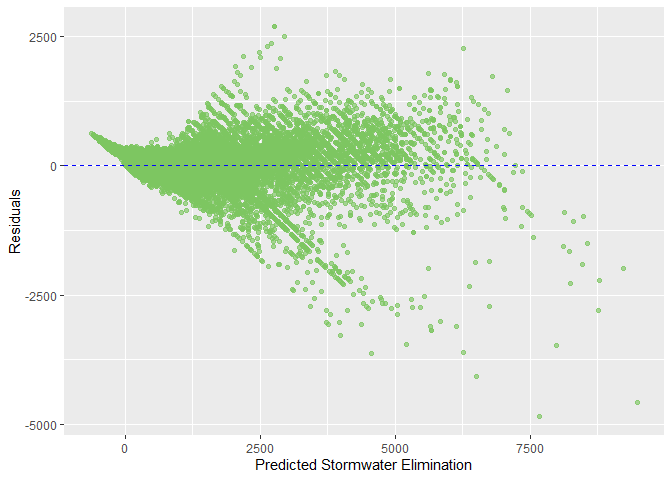

*The residual plot shows a more or less random scatter around 0, which makes a linear model potentially appropriate. However, There is a little bit of a fan shape (even with added squared terms in the model), which indicates a potential violation of the constant variance assumption for the linear model.*

Let’s construct a new model removing height since it had a relatively low slope in our previous model.

```
## # A tibble: 16 × 5
##    term                            estimate std.error statistic   p.value
##    <chr>                              <dbl>     <dbl>     <dbl>     <dbl>
##  1 (Intercept)                       -354.     87.8       -4.04  5.47e- 5
##  2 growth_space_typeMedian            314.     72.1        4.36  1.29e- 5
##  3 growth_space_typeOpen              261.     70.2        3.72  2.02e- 4
##  4 growth_space_typeRaised Planter    480.     98.3        4.88  1.07e- 6
##  5 growth_space_typeRestricted        300.     71.1        4.22  2.44e- 5
##  6 growth_space_typeTree Lawn         275.     70.2        3.92  8.87e- 5
##  7 growth_space_typeWell/Pit          317.     70.2        4.52  6.27e- 6
##  8 diameter_base_height               132.      0.289    455.    0
##  9 I(diameter_base_height)             NA      NA         NA    NA
## 10 overhead_utilitiesYes              -51.1     5.25      -9.74  2.25e-22
## 11 conditionVery Good                -560.     56.6       -9.91  4.28e-23
## 12 conditionGood                     -193.     52.9       -3.64  2.71e- 4
## 13 conditionFair                     -316.     52.9       -5.98  2.20e- 9
## 14 conditionPoor                     -735.     53.3      -13.8   4.17e-43
## 15 conditionCritical                 -943.     54.8      -17.2   4.66e-66
## 16 conditionDead                     -828.     54.8      -15.1   2.90e-51
```

```
## # A tibble: 1 × 12
##   r.squared adj.r.squared sigma statistic p.value    df   logLik     AIC     BIC
##       <dbl>         <dbl> <dbl>     <dbl>   <dbl> <dbl>    <dbl>   <dbl>   <dbl>
## 1     0.901         0.901  408.    17191.       0    14 -196892. 393815. 393946.
## # ℹ 3 more variables: deviance <dbl>, df.residual <int>, nobs <int>
```

*$R^2$ is now 0.9009, which is a little less than previously. All the p values are less than 0.05, which indicates all predictor variables included in the model are statistically significant at the 0.05 significance level.*

Lastly, we are going to calculate the RMSE for both models in order to compare their prediction accuracy and assess which model performs better in terms of minimizing the error between predicted and observed values.

```
## [1] 352.6942
```

```
## [1] 402.1362
```

*The first model (with height) has a lower RMSE, so it is better than the first model in terms of minimizing error between predicted and observed values.*

Thus, we can conclude that `height`, `diameter_base_height`, `growth_space_type`, `overhead_utilities`, and `condition` are factors that significantly influence stormwater elimination.

### 2. Do certain tree species provide more ecological benefits, such as increased stormwater elimination or higher capture of CO$_2$?

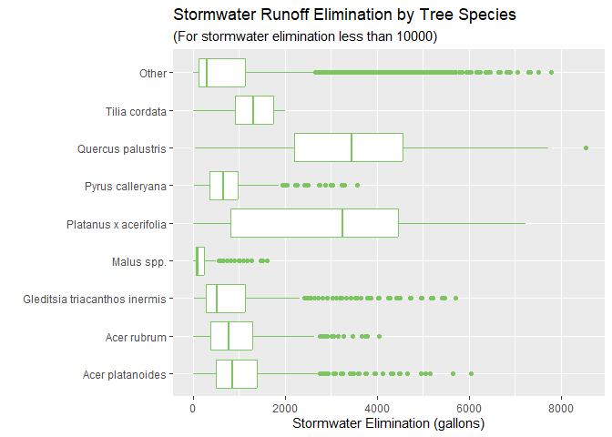

*All the distributions are right-skewed with high outliers, except for ‘Platanus x acerifolia’ and ‘Tilia cordata’. ‘Platanus x acerifolia’ and ‘Quercus palustris’ trees have much higher median stormwater elimination and IQR values compared to other tree species. ‘Malus spp.’ has the lowest median, Q1, Q3, and IQR values. Additionally, ‘Acer rubrum’ and ‘Acer platanoides’ have very similar distributions (similar median, Q1, Q2, and IQR values), which could be explained by the fact that they belong to the same genus (Maple).*

Let’s explore further whether species from the same genus have similar distributions of stormwater elimination.

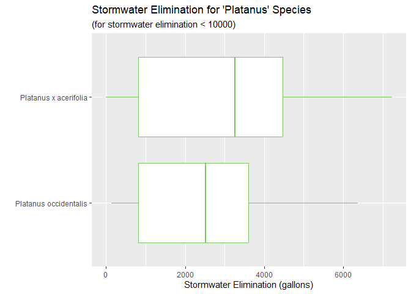

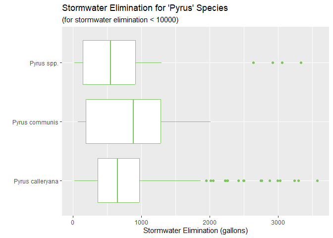

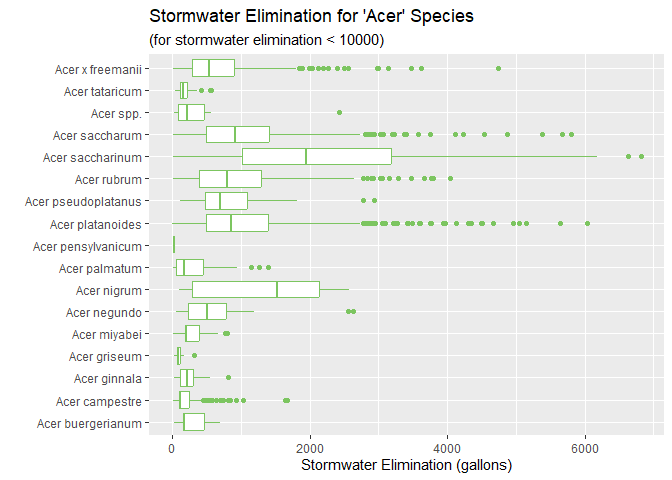

*Acer species don’t seem to have similar distributions of stormwater elimination after all. However, Platanus and Pyrus species do seem to have relatively similar distributions of stormwater elimination amount.*

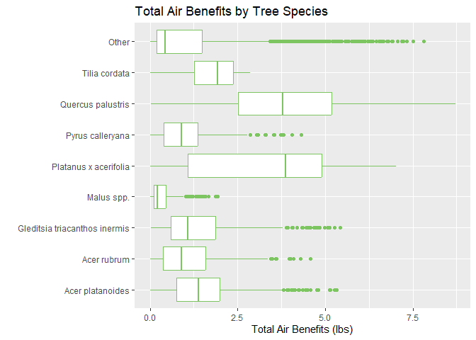

*‘Platanus x acerifolia’ and ‘Quercus palustris’ trees have the highest median air quality benefits and IQR values as well, and ‘Malus spp.’ has the lowest median, Q1, Q3, and IQR values. The shapes of the distributions vary by species. Some are right-skewed, such as ‘Malus spp.’ or left-skewed, such as ‘Platanus x acerifolia’, while others are more or less symmetric, such as ‘Acer platanoides’ or ‘Pyrus calleryana’.*

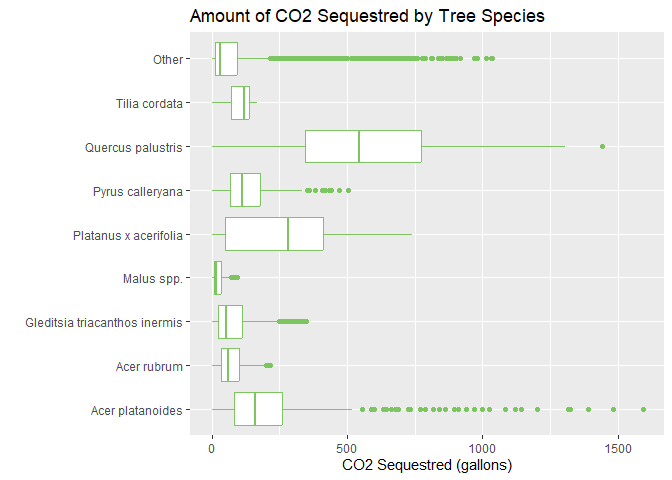

**Overall, it does seem like certain tree species provide more ecological benefits. ‘Platanus x acerifolia’ and ‘Quercus palustris’ trees absorb more stormwater, provide more air quality benefits, and capture more CO$_2$, on average, than any other tree species.**

### 3. Can tree dimensions predict their impact on air quality?

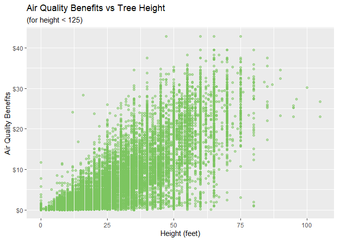

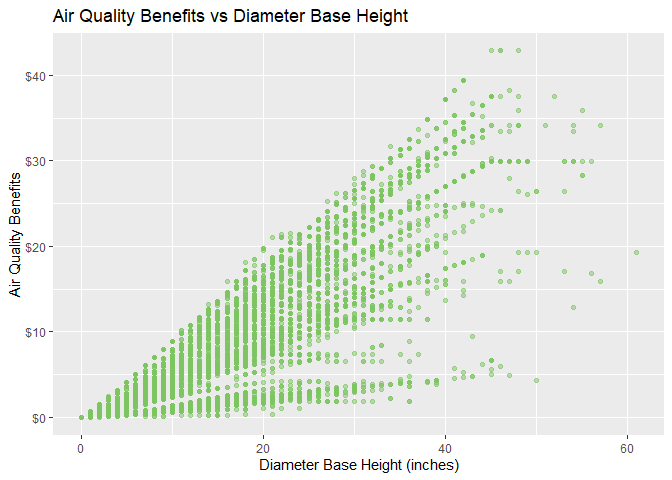

*Overall, there does seem to be a weak to moderate positive linear relationship between tree dimensions (height and diameter base height) and air quality benefits. The trees with the highest dimensions tend to have the highest total air quality benefits.*

#### ★ Linear Regression: Can tree dimensions predict their impact on air quality?

We are going to fit a linear regression model to analyze whether tree dimensions can help predict their overall air quality benefits. Let’s consider the following predictors: `height`, `width`, and `diameter_base_height`. **Note that the data used for this section excludes trees taller than 125 feet (outliers).**

```
## # A tibble: 4 × 5
##   term                 estimate std.error statistic   p.value
##   <chr>                   <dbl>     <dbl>     <dbl>     <dbl>
## 1 (Intercept)           -2.07     0.0364      -56.8 0
## 2 height                 0.0293   0.00223      13.2 1.40e- 39
## 3 width                  0.120    0.00387      30.9 1.53e-206
## 4 diameter_base_height   0.582    0.00338     172.  0
```

```
## # A tibble: 1 × 12
##   r.squared adj.r.squared sigma statistic p.value    df  logLik     AIC     BIC
##       <dbl>         <dbl> <dbl>     <dbl>   <dbl> <dbl>   <dbl>   <dbl>   <dbl>
## 1     0.843         0.843  2.73    47539.       0     3 -64232. 128474. 128515.
## # ℹ 3 more variables: deviance <dbl>, df.residual <int>, nobs <int>
```

Next, let’s look at a residual plot for the previous model to assess the appropriateness of a linear model:

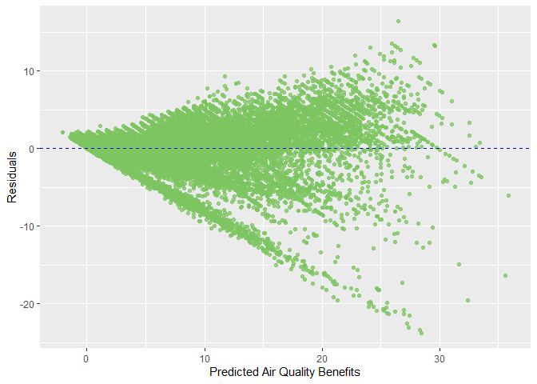

*The residual plot shows a more or less random scatter around 0, which makes a linear model potentially appropriate. However, There is a little bit of a fan shape, which indicates a potential violation to the constant variance assumption.*

Let’s construct a new model removing height since it has a very small slope in the current model.

```
## # A tibble: 5 × 5
##   term                      estimate std.error statistic   p.value
##   <chr>                        <dbl>     <dbl>     <dbl>     <dbl>
## 1 (Intercept)               -1.80     0.0476       -37.9 6.71e-306
## 2 width                      0.312    0.00837       37.3 8.82e-297
## 3 I(width^2)                -0.00564  0.000255     -22.2 8.75e-108
## 4 diameter_base_height       0.455    0.00602       75.6 0
## 5 I(diameter_base_height^2)  0.00433  0.000157      27.7 6.15e-166
```

```
## # A tibble: 1 × 12
##   r.squared adj.r.squared sigma statistic p.value    df  logLik     AIC     BIC
##       <dbl>         <dbl> <dbl>     <dbl>   <dbl> <dbl>   <dbl>   <dbl>   <dbl>
## 1     0.848         0.848  2.69    36987.       0     4 -63821. 127653. 127702.
## # ℹ 3 more variables: deviance <dbl>, df.residual <int>, nobs <int>
```

Lastly, we are going to calculate the RMSE values for both models and compare them.

```
## [1] 2.598626
```

```
## [1] 2.547927
```

Overall, tree dimensions appear to be good predictors for tree impact on air quality.

### 4. Do trees with overhead utilities grow differently or provide fewer benefits?

Let’s first look at summary statistics of trees dimensions by presence of overhead utilities.

```
## # A tibble: 2 × 5
##   overhead_utilities mean_height mean_width mean_diameter_base count
##   <chr>                    <dbl>      <dbl>              <dbl> <int>
## 1 No                        27.4       8.63               10.9 19534
## 2 Yes                       27.8       8.77               12.9 13596
```

*Trees with and without overhead utilities have very similar mean dimensions.*

Let’s now look at the distributions of tree dimensions by overhead utilities being present or not.

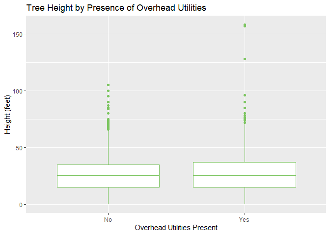

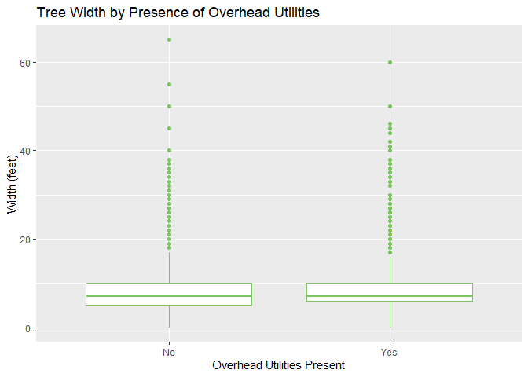

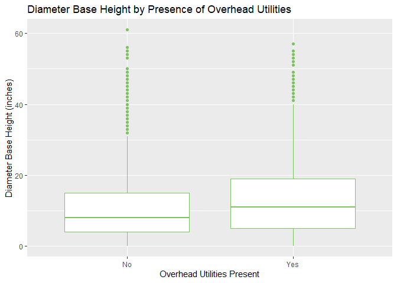

*Tree dimensions vary between trees with and without overhead utilities. The distributions for ‘height’ and ‘width’ are similar, with approximately the same median values across both groups. However, trees with overhead utilities have a wider IQR for ‘height’ and ‘diameter_base_height’, along with a higher median for ‘diameter_base_height’. All distributions are right-skewed with many high outliers.*

Looking at summary statistics and distributions of tree benefits by presence of overhead utilities also showed distributions that are not exactly the same. Thus, both tree dimensions and tree benefits are potential predictors of a tree having overhead utilities or not.

#### ★ Logistic regression: Classifying trees as having overhead utilities or not

Next, we are going to fit a logistic regression model to determine whether trees with certain dimensions and benefits are found near overhead utilities. Let’s consider 6 predictors: `height`, `width`, `diameter_base_height`, `growth_space_area`, `stormwater_elimination`, and `total_air_benefits`.

```
## # A tibble: 7 × 5
##   term                     estimate  std.error statistic   p.value
##   <chr>                       <dbl>      <dbl>     <dbl>     <dbl>
## 1 (Intercept)            -0.249     0.0312         -7.98 1.51e- 15
## 2 height                 -0.0341    0.00181       -18.8  4.38e- 79
## 3 width                  -0.0115    0.00312        -3.69 2.27e-  4
## 4 diameter_base_height    0.123     0.00454        27.1  2.69e-161
## 5 growth_space_area      -0.0000591 0.00000315    -18.8  1.65e- 78
## 6 stormwater_elimination -0.000407  0.0000462      -8.83 1.08e- 18
## 7 total_air_benefits      0.0157    0.00793         1.98 4.78e-  2
```

```
## # A tibble: 1 × 8
##   null.deviance df.null  logLik    AIC    BIC deviance df.residual  nobs
##           <dbl>   <int>   <dbl>  <dbl>  <dbl>    <dbl>       <int> <int>
## 1        35906.   26503 -17275. 34563. 34621.   34549.       26497 26504
```

*The AIC value for this model is 34563.46, and all the p-values are significant (less than 0.05).*

*The variables `diameter_base_height` and `total_air_benefits` have a positive association with a tree having overhead utilities while `height`, `width`, `growth_space_area`, and `stormwater_elimination` have a negative association with a tree having overhead utilities. However, all the coefficients are very small.*

Let’s add a couple of interaction terms to the model for predictors that may interact with each other:

```
## # A tibble: 10 × 5
##    term                            estimate  std.error statistic   p.value
##    <chr>                              <dbl>      <dbl>     <dbl>     <dbl>
##  1 (Intercept)                   -0.209     0.0477         -4.37 1.22e-  5
##  2 height                        -0.0326    0.00213       -15.3  7.15e- 53
##  3 width                         -0.0399    0.00833        -4.79 1.65e-  6
##  4 diameter_base_height           0.113     0.00505        22.4  1.12e-110
##  5 growth_space_area             -0.0000607 0.00000319    -19.0  7.55e- 81
##  6 stormwater_elimination         0.000201  0.000146        1.38 1.67e-  1
##  7 total_air_benefits            -0.0310    0.0262         -1.19 2.36e-  1
##  8 height:width                   0.000681  0.000181        3.77 1.64e-  4
##  9 height:stormwater_elimination -0.0000127 0.00000330     -3.86 1.15e-  4
## 10 height:total_air_benefits      0.00115   0.000638        1.80 7.22e-  2
```

```
## # A tibble: 1 × 8
##   null.deviance df.null  logLik    AIC    BIC deviance df.residual  nobs
##           <dbl>   <int>   <dbl>  <dbl>  <dbl>    <dbl>       <int> <int>
## 1        35906.   26503 -17240. 34499. 34581.   34479.       26494 26504
```

*Adding interaction terms yielded a better AIC (34563.46 to 34499.24) but higher p-values for `stormwater_elimination` and `total_air_benefits`. Thus, we are going to proceed with the initial model.*

Lastly, let’s generate the confusion matrix and the ROC curve for the initial model to see how well the model classifies whether a tree has overhead utilities or not using “new” observations (our test data). We will use 0.5 as our probability cut-off.

```
## Confusion Matrix and Statistics
##
##           Reference
## Prediction    0    1
##          0 3485 2040
##          1  449  652
##
##                Accuracy : 0.6244
##                  95% CI : (0.6126, 0.636)
##     No Information Rate : 0.5937
##     P-Value [Acc > NIR] : 1.826e-07
##
##                   Kappa : 0.1412
##
##  Mcnemar's Test P-Value : < 2.2e-16
##
##             Sensitivity : 0.2422
##             Specificity : 0.8859
##          Pos Pred Value : 0.5922
##          Neg Pred Value : 0.6308
##              Prevalence : 0.4063
##          Detection Rate : 0.0984
##    Detection Prevalence : 0.1662
##       Balanced Accuracy : 0.5640
##
##        'Positive' Class : 1
##
```

*The accuracy rate for this model is 62.44% (the model only got 62.44% of the predictions overall right), which is not very high. Additionally, the sensitivity is pretty low (0.2422) compared to the specificity (0.8859), which indicates that there were many trees that were classified as not having overhead utilities when in reality they do have overhead utilities (false negatives).*

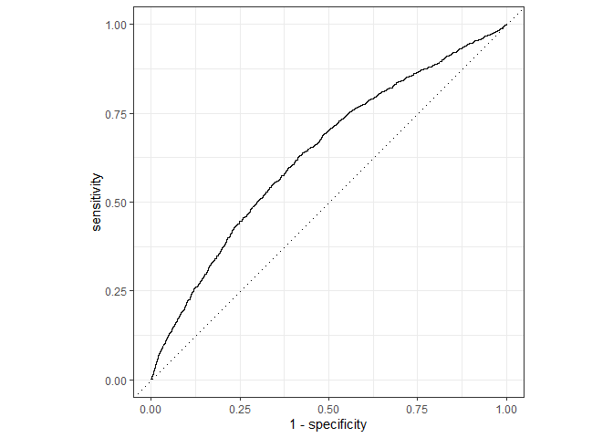

```
## # A tibble: 1 × 3
##   .metric .estimator .estimate
##   <chr>   <chr>          <dbl>
## 1 roc_auc binary         0.637
```

*The AUC is 0.6366, which isn’t much higher than 0.5, so this model doesn’t seem to be predicting the presence of overhead utilities very well.*

### 5. Is there a significant difference in the CO$_2$ benefits between trees located in residential areas versus vacant or industrial areas?

To answer this question, let’s look at the distribution of total CO$_2$ benefits for the 3 areas of interest.

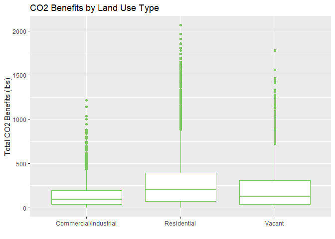

*Trees in residential areas have a higher median, Q1, Q3, and IQR values for total CO$_2$ benefits compared to trees in industrial or vacant areas. Trees in industrial areas have the lowest median total CO$_2$ benefits, which is interesting because trees in those areas are expected to be exposed to more CO$_2$. All distributions are right-skewed with many high outliers.*

Thus, there does seem to be a significant difference in the CO$_2$ benefits between trees located in residential areas versus vacant or industrial areas.

#### ★ Logistic regression: Classifying trees as being located in a residential area or an industrial area

Note that each of the predictor variables have been previously explored individually, and the distributions for the numeric variables were unimodal and right-skewed with many high outliers. Exploring the relationship between `land_use` and each of the predictor variables showed distributions that varied by a tree’s location being a residential area or an industrial area (the graph of land use by presence of overhead utilities is shown below for instance). Therefore, there does seem to be a relationship between the land use type of a tree and all the potential predictors.

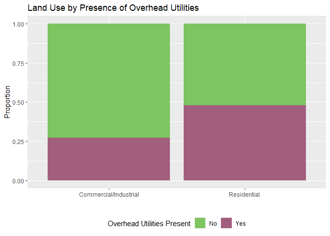

Next, we are going to fit a logistic regression model to predict the location of a tree (residential or industrial area) from our predictor variables.

```
## # A tibble: 8 × 5
##   term                       estimate  std.error statistic   p.value
##   <chr>                         <dbl>      <dbl>     <dbl>     <dbl>
## 1 (Intercept)               -0.397    0.0507         -7.82 5.38e- 15
## 2 co2_benefits_totalco2_lbs -0.00660  0.000515      -12.8  1.49e- 37
## 3 height                    -0.0113   0.00314        -3.59 3.29e-  4
## 4 diameter_base_height       0.400    0.0140         28.5  2.14e-178
## 5 growth_space_area          0.000202 0.00000830     24.3  1.47e-130
## 6 electricity_benefits      -0.287    0.0152        -18.8  5.33e- 79
## 7 total_air_benefits         0.292    0.0277         10.6  3.80e- 26
## 8 overhead_utilitiesYes      0.792    0.0439         18.1  5.90e- 73
```

```
## # A tibble: 1 × 8
##   null.deviance df.null logLik    AIC    BIC deviance df.residual  nobs
##           <dbl>   <int>  <dbl>  <dbl>  <dbl>    <dbl>       <int> <int>
## 1        19811.   21418 -7715. 15446. 15510.   15430.       21411 21419
```

*The AIC value for this model is 15446.11, and all the p-values are significant (less than 0.05).*

*The variables `diameter_base_height`, `growth_space_area`, and `total_air_benefits` have a positive association with a tree being located in a residential area while all the other quantitative variables have a negative association with a tree being located in a residential area.*

Let’s add a couple of interaction terms:

```
## # A tibble: 12 × 5
##    term                                estimate   std.error statistic  p.value
##    <chr>                                  <dbl>       <dbl>     <dbl>    <dbl>
##  1 (Intercept)                       0.172      0.0820           2.10 3.58e- 2
##  2 co2_benefits_totalco2_lbs        -0.0112     0.00172         -6.52 6.82e-11
##  3 height                           -0.0336     0.00440         -7.65 2.07e-14
##  4 diameter_base_height              0.247      0.0258           9.57 1.04e-21
##  5 growth_space_area                 0.000276   0.0000187       14.8  2.55e-49
##  6 electricity_benefits             -0.280      0.0159         -17.6  4.32e-69
##  7 total_air_benefits                0.516      0.0706           7.30 2.82e-13
##  8 overhead_utilitiesYes             0.800      0.0441          18.2  1.28e-73
##  9 co2_benefits_totalco2_lbs:height  0.000125   0.0000515        2.43 1.49e- 2
## 10 height:diameter_base_height       0.00571    0.000908         6.28 3.29e-10
## 11 height:growth_space_area         -0.00000338 0.000000655     -5.15 2.56e- 7
## 12 height:total_air_benefits        -0.00763    0.00209         -3.65 2.64e- 4
```

```
## # A tibble: 1 × 8
##   null.deviance df.null logLik    AIC    BIC deviance df.residual  nobs
##           <dbl>   <int>  <dbl>  <dbl>  <dbl>    <dbl>       <int> <int>
## 1        19811.   21418 -7630. 15284. 15379.   15260.       21407 21419
```

*Adding interaction terms yielded a better AIC (15446.11 to 15283.73) while keeping the p-values significant (less than 0.05). Thus, we are going to proceed with this model including interaction terms.*

Lastly, let’s generate the confusion matrix and the ROC curve for the model including interaction terms to see how well the model classifies whether a tree is located in a residential area or not using “new” observations (our test data). We will use 0.5 as our probability cut-off.

```
## Confusion Matrix and Statistics
##
##           Reference
## Prediction    0    1
##          0  184  130
##          1  768 4296
##
##                Accuracy : 0.833
##                  95% CI : (0.8228, 0.8429)
##     No Information Rate : 0.823
##     P-Value [Acc > NIR] : 0.02731
##
##                   Kappa : 0.2224
##
##  Mcnemar's Test P-Value : < 2e-16
##
##             Sensitivity : 0.9706
##             Specificity : 0.1933
##          Pos Pred Value : 0.8483
##          Neg Pred Value : 0.5860
##              Prevalence : 0.8230
##          Detection Rate : 0.7988
##    Detection Prevalence : 0.9416
##       Balanced Accuracy : 0.5820
##
##        'Positive' Class : 1
##
```

*The accuracy rate for this model is 83.3% (the model got 83.3% of the predictions overall right), which is pretty high. The sensitivity is also pretty high (0.9706) while the specificity is low (0.1933), which indicates that there were many trees that were classified as being located in a residential area when in reality they are located in an industrial area (false positives).*

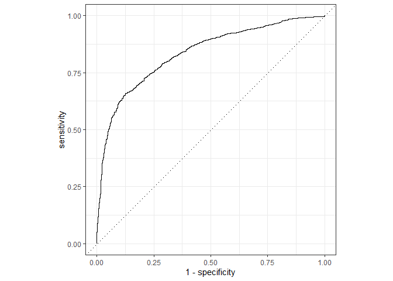

```
## # A tibble: 1 × 3
##   .metric .estimator .estimate
##   <chr>   <chr>          <dbl>
## 1 roc_auc binary         0.835
```

*The AUC is 0.8351, which is much higher than 0.5, so this model is predicting whether a tree is located in a residential area fairly well.*

### 6. How are trees distributed across different neighborhoods or wards in Pittsburgh?

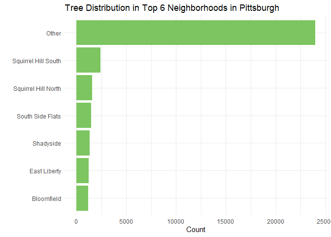

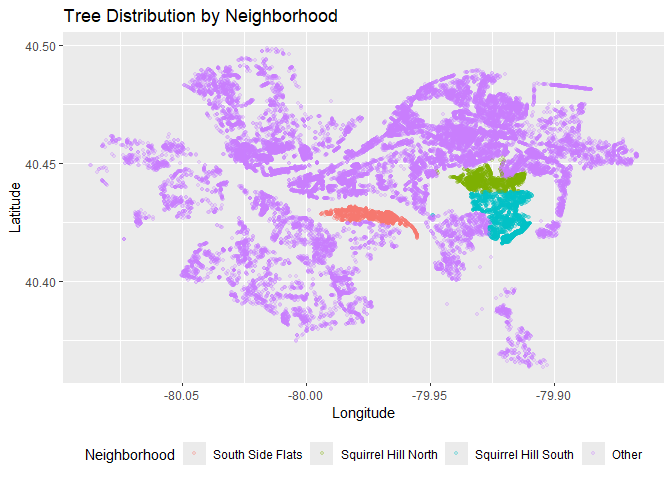

### 7. How are trees distributed in Pittsburgh? Are there clusters of some tree species within certain areas of the city?

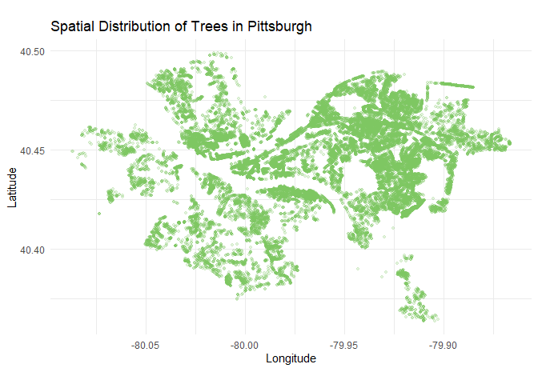

*In Pittsburgh, trees are distributed more or less evenly across the city, with the North East having the highest cluster of trees.*

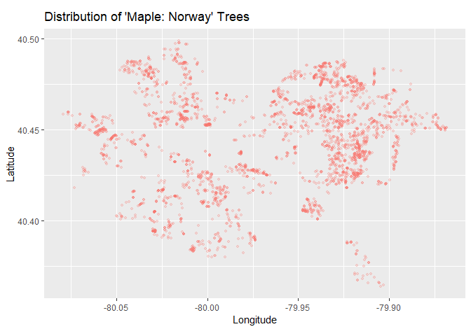

*Maple trees, for instance, are slightly more clustered in the North East of the city (which could be explained by the fact that there are more trees overall in the North East), although they are present all over the city as well.*

### 8. What is the spatial distribution of trees in poor condition? in excellent condition?

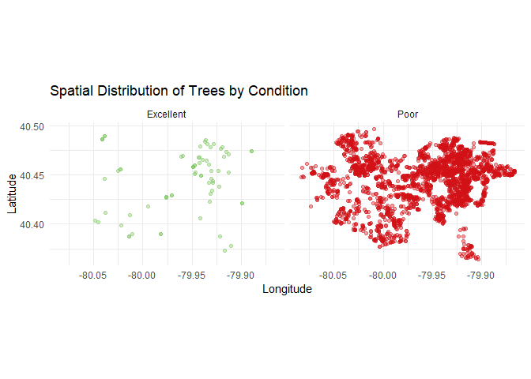

*There are many trees in poor condition distributed all over the city, and there are fewer trees in excellent condition distributed in most part of the city. There aren’t many trees in excellent condition in the North West or South West of the city.*

### 9. What is the spatial distribution of trees providing the highest total benefits? What is the spatial distribution of trees providing the most significant stormwater management benefits?

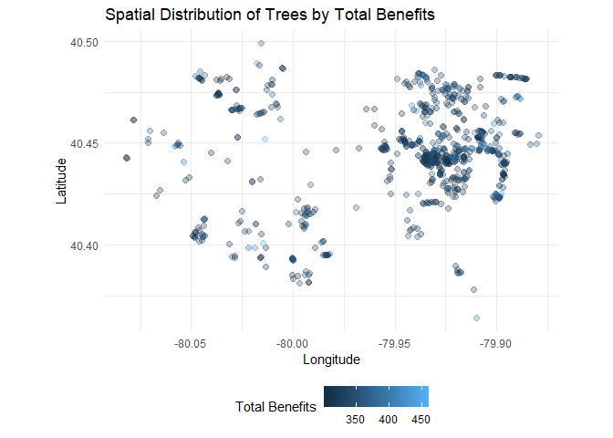

*Trees providing the highest total benefits seem to be more present in the North East and South West of the city.*

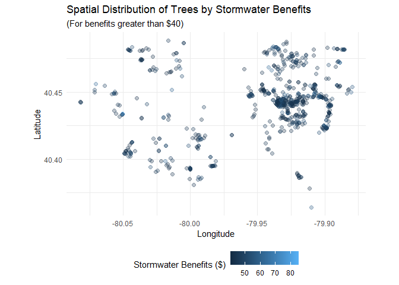

*Trees providing the most stormwater management benefits are more or less evenly distributed across the city, with a cluster in the North East, which again could be explained by the fact that there are more trees in the North East overall.*

### 10. Do trees closer to each other in certain areas provide cumulative environmental benefits (e.g., stormwater management or CO$_2$ reduction)?

To answer this question, we are going to aggregate the benefits provided by trees within a 3-kilometer radius and explore how proximity affects their cumulative environmental impact. Then, we will also aggregate the trees based on the street variable to see if the results are similar.

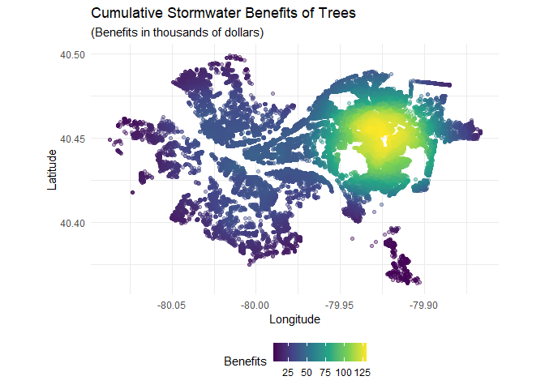

*Trees in the North East that are close to each other seem to provide more cumulative environmental benefits. However, this may be explained by the fact that there are typically more trees within a given radius in the North East than in other parts of the city, which increases the cumulative environmental benefits. Additionally, previous research questions have shown that trees in the North East have the highest environmental benefits individually (based on other factors such as their species) and are in a better condition (‘Excellent’) on average. Thus, the cumulative benefits shown on this graph may be due to high individual benefits of each tree rather than high total benefits of clusters of trees.*

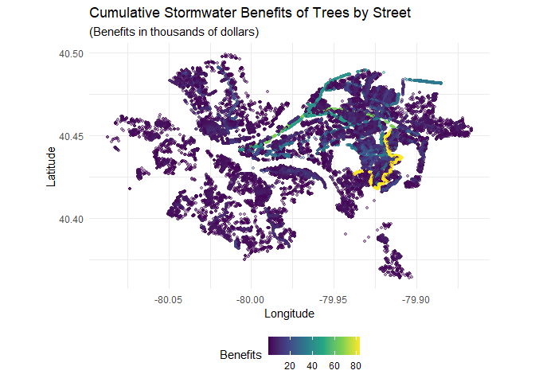

*Similarly, trees that are on the same street in the North East of the city seem to have higher cumulative benefits.*

## Conclusion

This paper explored the ecological benefits provided by trees in Pittsburgh, focusing on factors influencing stormwater management, CO$_2$ capture, air quality, and spatial distributions. The analyses employed both linear and logistic regression models, alongside spatial visualizations, to uncover patterns and relationships between variables in the dataset. The results showed that tree attributes such as diameter at base height, growth space type, overhead utilities, and condition significantly influence stormwater elimination. Furthermore, specific species like *‘Platanus x acerifolia’* and *‘Quercus palustris’* were found to provide the highest benefits across multiple ecological metrics. Spatially, trees were generally well-distributed across the city, with the North East showing higher environmental contributions, likely due to species composition and tree condition.

However, several limitations affected the reliability of these findings. The residual plots for the linear regression models revealed a slight fan-shaped pattern, indicating potential heteroscedasticity and suggesting that model assumptions of constant variance may not fully hold. Outliers were another concern, as many were filtered to improve the models, but their removal may have excluded important variation. The dataset itself, last updated in 2020, may not reflect current conditions, limiting the validity of conclusions drawn about tree health and benefits. The logistic regression model predicting the presence of overhead utilities also showed low predictive power, emphasizing the need for additional or more relevant predictors.

If the study were to be conducted again, collecting more recent and comprehensive data would be a priority to improve the accuracy and applicability of the findings. Addressing model assumptions through transformations or alternative modeling approaches could also improve statistical validity. Despite these limitations, this analysis highlights the significant contributions of urban trees to environmental sustainability and offers a foundation for future studies aimed at optimizing urban forestry strategies.